# Effect of different factors on borrower APR

## by Shady Mohammed Hussein

## Investigation overview:

### Our main purpose here is to investigate some variables that affect the APR of an individual.

### Preliminary Exploration:

- This data set contains 113,937 loans with 81 variables on each loan, including loan amount, borrower rate (or interest rate), current loan status, borrower income, and many others.

### First: Univariate Analysis:

## Distribution of Borrower APR

- We can see here the distribution is a multimodal one values ranging from 0.04 to 0.42 and a mean of 0.22.

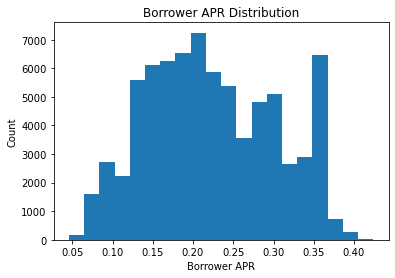

## Distribution of Income Ranges:

- We can see here that the highest demand on loans comes from those who earn 50k to 75k USD, and the lowest is for those who are not employed, they tend not to take loans.

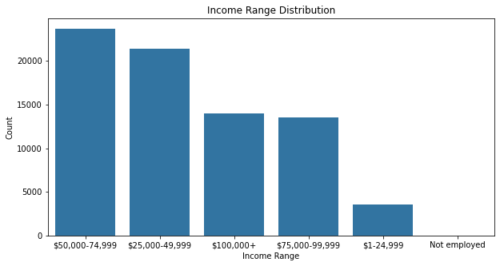

## Borrower APR by Prosper Score

- We can see that the highest APR rates are associated with the lowest Prosper scores, with gradual decrease in the APR rate as we approach the highest score of 10.

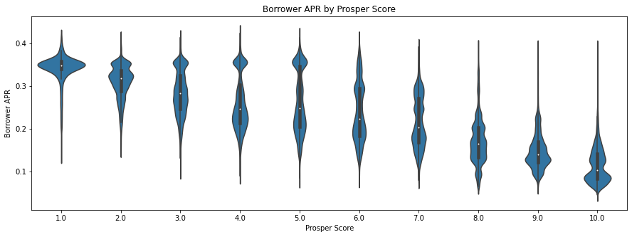

## Borrower APR by Income Range

- The borrower APR rate also related with the income ranges as we can see that the lowest income categories tend to have the highest APR rates and the rates go down as we go higher in income range.

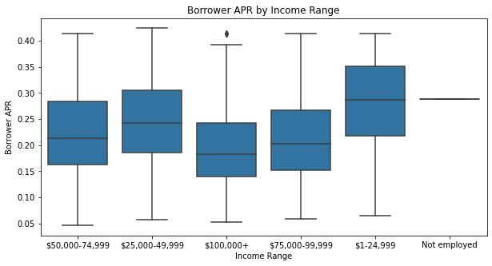

## Borrower APR by Income Range and Prosper Score

- By exploring the multivariate relation between the 3 variables, we find a very interesting finding. When we have a Prosper score higher than 8, actually the lowest income category seem to have the lowest APR rates. Interesting !.

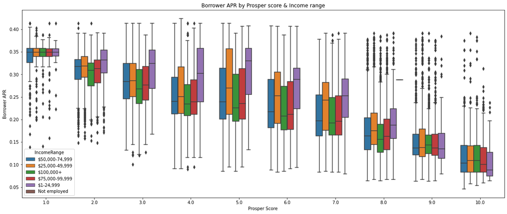